# Ma_ALY6000Project6

Zihan Ma

2023-02-18

**ALY6000 Introduction to Analytics**  
**Northeastern University**  
Zihan Ma  
Date: 02 - 18 - 2023

Project Report

Introduction

1. General topic:

The sales data set we have been working with is in excel format, and it’s a record for sales activities occur across multiple countries, markets, and company departments.It gives us a chances for understanding how company operates in different places on different product. One of the most quality data in this data sets is it shows many data that related to the product’s logistics cost. Because the shipping and logistics play critical role in global sales. As Kotler and Keller (2016) highlight the importance of logistics and supply chain management in global sales. Companies need to be able to optimize their shipping strategies to reduce costs and improve delivery times. The cost of shipping can have a significant impact on the profitability of a product, and managing returns and minimizing losses can significantly impact a company’s bottom line.

2. Data set description:

This data set have 1000 observes. It record each sale’s date, product ID, location, division, shipping related information and after sale information. There are no missing data in the data sources, but part of the number in the excel file is being rounded.

3. Descriptive statistics:

Descriptive statistics can be used to summarize and analyze large amounts of data, identifying trends, patterns, and relationships between variables.

When a retail company is looking to optimize its pricing strategy to increase sales and revenue. They collect data on pricing and sales for a specific product category, and uses descriptive statistics to analyze the data and identify trends. Based on the analysis, the company identifies that sales are highest for products priced between $50 and $70, and that sales are primarily driven by online channels and younger customers. Using this information, the company adjusts its pricing strategy to offer more products in this price range and increase online promotions and advertising targeted at younger customers. As a result of these changes, the company sees an increase in sales and revenue.

4. Inferential statistics:

Inferential statistics is the process of using statistical analyses to draw conclusions about a population based on a sample of data. This enables businesses to make predictions and draw conclusions about their operations, customers, and market dynamics.

A manufacturing company is looking to improve the efficiency of its production processes. The company collects data on the time it takes to produce a specific product, and then performs a hypothesis test to determine whether the mean production time is statistically different from a target value. Based on the results of the test, the company identifies that the mean production time is higher than the target value, indicating that there may be opportunities to improve the efficiency of the production process.

5. R Script versus R Markdown:

Similarities:

They are all source file that use R language to help the data analyse process. And they both can be edit on the RStudio.

Differences:

R Markdown can produce html/word/pdf file that use to present to people that don’t konw a lot about R. But R Markdown cannot be run as a progrom as R does.

```r
# Libraries used in this markdown
library(rmarkdown)
library(readxl)
library(readr)
library(tidyverse)
library(dplyr)
library(knitr)
library(kableExtra)
library(magrittr)
library(RColorBrewer)
library(FSA)
library(ggplot2)

# Data imported from DataSets/M6_project_dataset(2023).xlsx
library(readxl)
M6dataset <- read_excel("DataSets/M6_project_dataset(2023).xlsx")
```

Task 1 **A simple present of the constriction of the source data.**

```r
# {r Task 1}

M6dataset_forsummary = subset(M6dataset, select = c(OrderDate, Product_Price, Quantity, Shipping_Cost_Each, Returns, Loss_Per_Return))

summary(M6dataset_forsummary)%>%
  kbl(caption = 'M6dataset Summary', align = "cccccc") %>%
  kable_styling(bootstrap_options = c("striped", "hover", "condensed", "responsive"))
```

M6dataset Summary

|  | OrderDate | Product_Price | Quantity | Shipping_Cost_Each | Returns | Loss_Per_Return |
| --- | --- | --- | --- | --- | --- | --- |
|  | Min. :2020-01-01 00:00:00.0 | Min. : 151.9 | Min. : 20.0 | Min. : 0.000 | Min. : 6.00 | Min. : 18.23 |
|  | 1st Qu.:2020-05-09 00:00:00.0 | 1st Qu.: 361.1 | 1st Qu.: 45.0 | 1st Qu.: 3.890 | 1st Qu.: 14.00 | 1st Qu.: 73.54 |
|  | Median :2020-08-06 00:00:00.0 | Median : 501.4 | Median :133.0 | Median : 8.585 | Median : 40.00 | Median : 145.66 |
|  | Mean :2020-07-24 05:12:28.7 | Mean : 548.9 | Mean :158.5 | Mean :14.325 | Mean : 47.59 | Mean : 168.92 |
|  | 3rd Qu.:2020-10-19 00:00:00.0 | 3rd Qu.: 684.3 | 3rd Qu.:251.2 | 3rd Qu.:21.413 | 3rd Qu.: 75.25 | 3rd Qu.: 240.63 |
|  | Max. :2020-12-25 00:00:00.0 | Max. :3558.4 | Max. :400.0 | Max. :59.710 | Max. :120.00 | Max. :1352.20 |

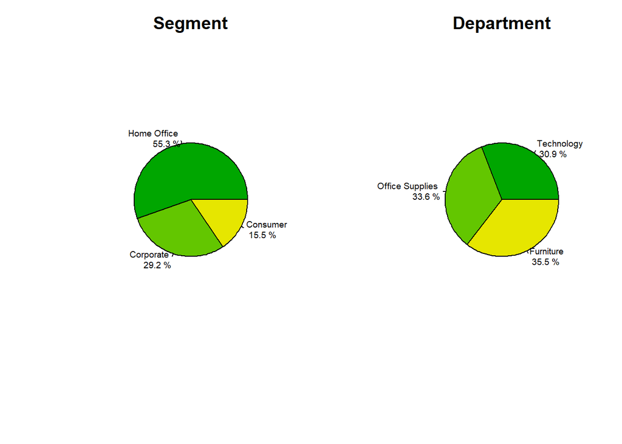

```r
par(mfrow=c(1,2),mar = c(10, 8, 0.5, 2), mai = c(1,1,0.5,0.2))

M6dataset_SegmentFrequency = table(M6dataset$Segment)

M6dataset_DepartmentFrequency = table(M6dataset$Department)


M6dataset_Segment = table(M6dataset$Segment)

M6dataset_Department = table(M6dataset$Department)

pieLabels_Segment = paste(unique(M6dataset$Segment),
                  "\n",
                  round(100*M6dataset_SegmentFrequency/sum(M6dataset_SegmentFrequency), 1)
                  , "%")

pieLabels_Department = paste(unique(M6dataset$Department),
                  "\n",
                  round(100*M6dataset_DepartmentFrequency/sum(M6dataset_DepartmentFrequency), 1)
                  , "%")

pie(table(M6dataset$Segment),
    main = "Segment",
    labels = pieLabels_Segment,
    radius = 0.6,
    col = terrain.colors(6),
    border = "black",
    lty = 1,
    cex=0.6,
    font = 1
    )

pie(table(M6dataset$Department),
    main = "Department",
    labels = pieLabels_Department,
    radius = 0.6,
    col = terrain.colors(6),
    border = "black",
    lty = 1,
    cex=0.6,
    font = 1
    )
```

In the M6dataset Summary table, we got the basic over watch for most of numeral value, explicitly the 1stQu, 3rdQu and median, which gives us the distribution of the data set.

The pie chart of department shows 3 different components have very close market share, again, it also not indicate they have equual amont of sales.

Task 2 **Utilize box plot and a histogram to visualize the distribution of the shipping cost**

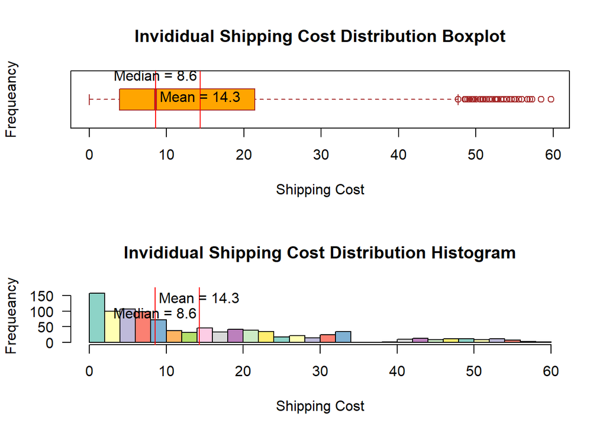

```r
# {r Task 2}

Shipping_Cost_Each = M6dataset$Shipping_Cost_Each
Task2means = mean(Shipping_Cost_Each)
Task2medians = median(Shipping_Cost_Each)

par(mfcol=c(2,1))

Shipping_Cost_Each %>%
  boxplot(main="Invididual Shipping Cost Distribution Boxplot",
          xlab="Shipping Cost",
          ylab="Frequeancy",
          horizontal = T,
          col="orange",
          border="brown")

abline(v = Task2means, col = "red")
text(x = Task2means, y = 0.8, labels = paste0("Mean = ", round(Task2means, 1)), pos = 3)
abline(v = Task2medians, col = "red")
text(x = Task2medians, y = 1.2, labels = paste0("Median = ", round(Task2medians, 1)), pos = 3)

Shipping_Cost_Each %>%
  hist(main = "Invididual Shipping Cost Distribution Histogram",
     xlab="Shipping Cost",
     ylab="Frequeancy",
     las=1,
     ylim=c(0,170),
     col = brewer.pal(12, "Set3"),
     breaks = 40)

abline(v = Task2means, col = "red")
text(x = Task2means, y = 100, labels = paste0("Mean = ", round(Task2means, 1)), pos = 3)
abline(v = Task2medians, col = "red")
text(x = Task2medians, y = 50, labels = paste0("Median = ", round(Task2medians, 1)), pos = 3)
```

From two plot we can find out there are big amount of out liners on the right side of the graph, which indicates that the dataset is positively skewed. Positive skewness means that the tail of the distribution is longer on the right side than on the left side. This can happen when there are a few very large values in the dataset, which pull the mean towards the right side of the graph, as what we see here. This face means people are rarely want to buy a goods which have very high shipping cost.

Task 3 **The shipping cost in different market**

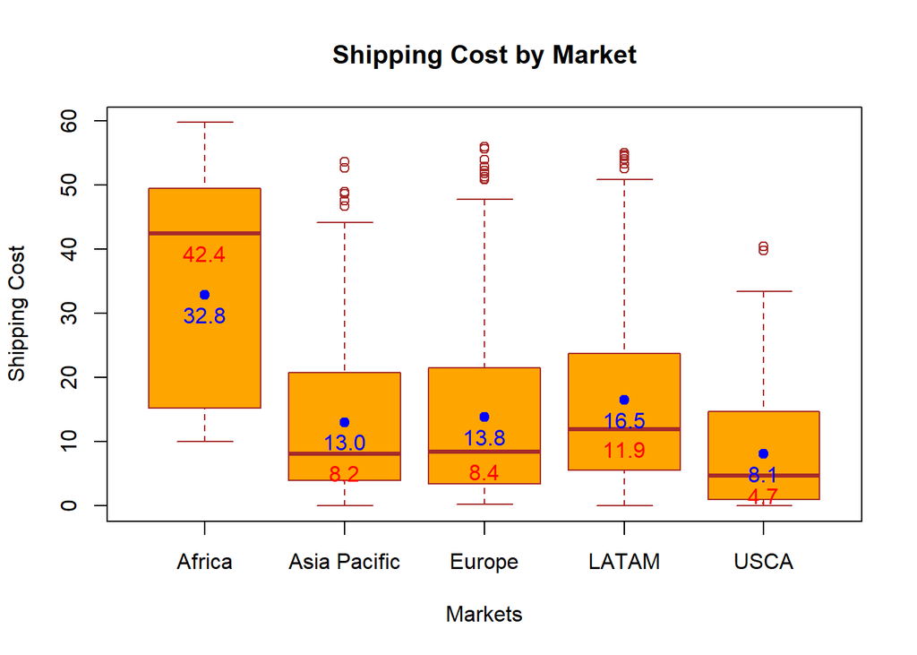

```r
# {r Task 3}

# Calculate median and mean values for each shipping mode
Task3medians <- tapply(M6dataset$Shipping_Cost_Each, M6dataset$Market, median)
Task3means <- tapply(M6dataset$Shipping_Cost_Each, M6dataset$Market, mean)


boxplot(Shipping_Cost_Each ~ Market,
        data = M6dataset,
        main = "Shipping Cost by Market",
        xlab = "Markets",
        ylab = "Shipping Cost",
        col="orange",
        border="brown")

# Add point and text labels for median and mean values to the plot

points(x = 1:nrow(Task3medians), y = Task3means, pch = 19, col = "blue")
text(x = 1:nrow(Task3medians), y = Task3means, labels = formatC(Task3means, format = "f", digits = 1), pos = 1, col = "blue")

text(x = 1:nrow(Task3medians), y = Task3medians, labels = formatC(Task3medians, format = "f", digits = 1), pos = 1, col = "red")
```